ANALYSIS OF WHITE WINES DATASET BY : NIKHIL BHASKAR ========================================================

```
##  [1] "X"                    "fixed.acidity"        "volatile.acidity"
##  [4] "citric.acid"          "residual.sugar"       "chlorides"
##  [7] "free.sulfur.dioxide"  "total.sulfur.dioxide" "density"
## [10] "pH"                   "sulphates"            "alcohol"
## [13] "quality"
```

# Univariate Plots Section

```
## 'data.frame':    4898 obs. of  13 variables:
##  $ X                   : int  1 2 3 4 5 6 7 8 9 10 ...
##  $ fixed.acidity       : num  7 6.3 8.1 7.2 7.2 8.1 6.2 7 6.3 8.1 ...
##  $ volatile.acidity    : num  0.27 0.3 0.28 0.23 0.23 0.28 0.32 0.27 0.3 0.22 ...
##  $ citric.acid         : num  0.36 0.34 0.4 0.32 0.32 0.4 0.16 0.36 0.34 0.43 ...
##  $ residual.sugar      : num  20.7 1.6 6.9 8.5 8.5 6.9 7 20.7 1.6 1.5 ...
##  $ chlorides           : num  0.045 0.049 0.05 0.058 0.058 0.05 0.045 0.045 0.049 0.044 ...
##  $ free.sulfur.dioxide : num  45 14 30 47 47 30 30 45 14 28 ...
##  $ total.sulfur.dioxide: num  170 132 97 186 186 97 136 170 132 129 ...
##  $ density             : num  1.001 0.994 0.995 0.996 0.996 ...
##  $ pH                  : num  3 3.3 3.26 3.19 3.19 3.26 3.18 3 3.3 3.22 ...
##  $ sulphates           : num  0.45 0.49 0.44 0.4 0.4 0.44 0.47 0.45 0.49 0.45 ...
##  $ alcohol             : num  8.8 9.5 10.1 9.9 9.9 10.1 9.6 8.8 9.5 11 ...
##  $ quality             : Ord.factor w/ 7 levels "3"<"4"<"5"<"6"<..: 4 4 4 4 4 4 4 4 4 4 ...
```

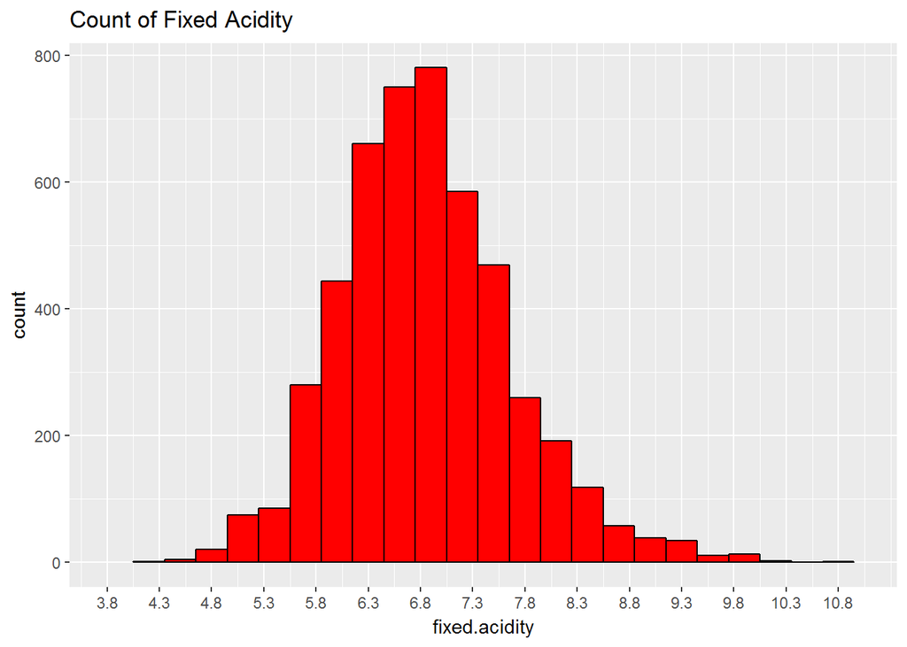

```r
ggplot(aes(x=fixed.acidity),data=wines_df)+
  geom_histogram(color=I('black'),fill=I('red'),binwidth = 0.3)+
  scale_x_continuous(limits = c(3.8,11),breaks = seq(3.8,11,0.5))+
  ggtitle('Count of Fixed Acidity')
```

Fixed acidity has a normalized curve with median at 6.8 and mean 6.855.

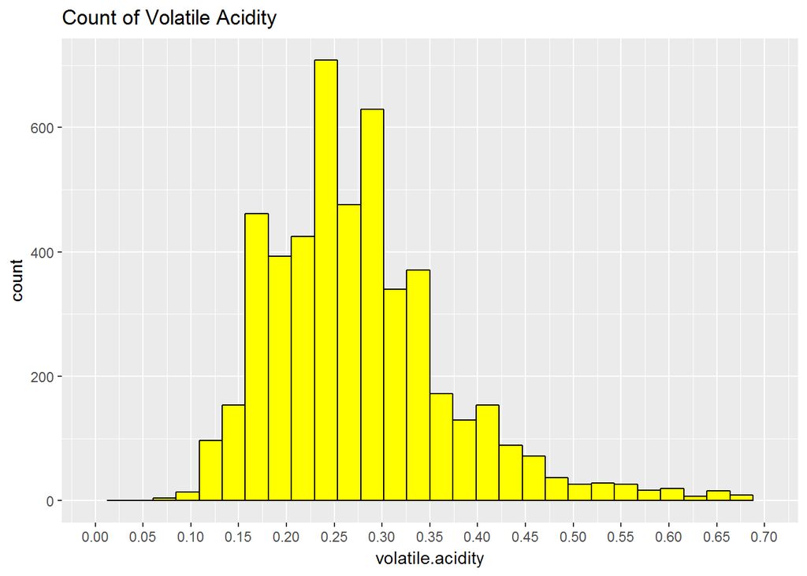

```r
ggplot(aes(x=volatile.acidity),data=wines_df)+
  geom_histogram(color=I('black'),fill=I('yellow'))+
  scale_x_continuous(limits = c(0,0.7),breaks = seq(0,0.7,0.05))+
  ggtitle('Count of Volatile Acidity')
```

volatile acidity has median of 0.26 and mean of 0.278 .

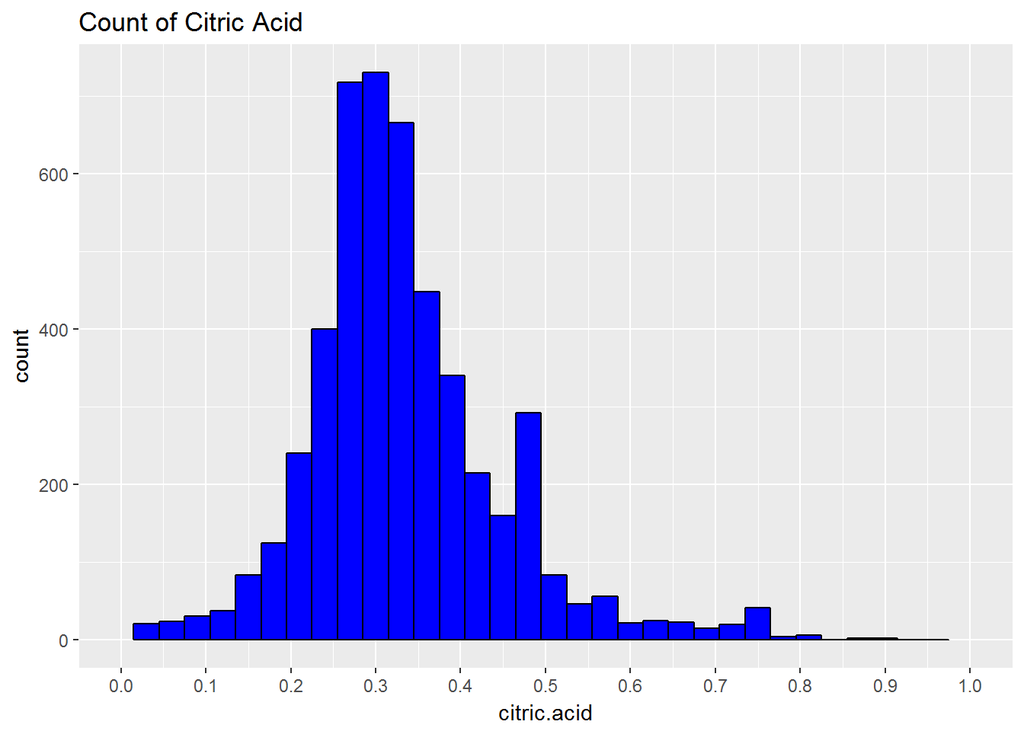

```r
ggplot(aes(x=citric.acid),data=wines_df)+
  geom_histogram(color=I('black'),fill=I('blue'),binwidth = 0.03)+
  scale_x_continuous(limits = c(0,1),breaks = seq(0,1,0.1))+
  ggtitle('Count of Citric Acid')
```

citric acid curve is normalized with median of 0.32 and mean 0f 0.33

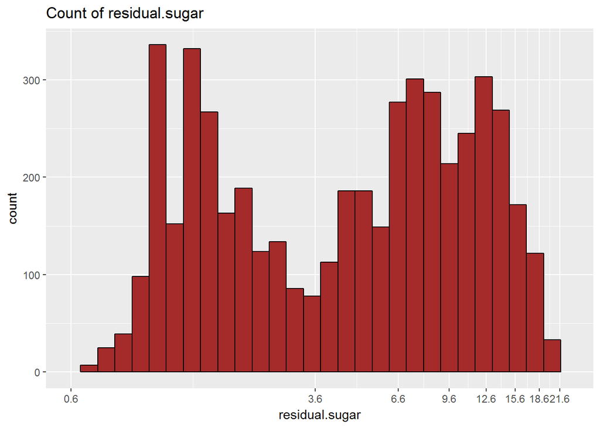

```r
ggplot(aes(x=residual.sugar),data=wines_df)+
  geom_histogram(color=I('black'),fill=I('brown'))+
  #scale_x_continuous(limits = c(0.6,22),breaks = seq(0.6,22,2))+
  scale_x_log10(limits=c(0.6,23),breaks=seq(0.6,23,3))+
  ggtitle('Count of residual.sugar')
```

residual sugar has a bimodal curve and to get bulk of data it is log transformed with median of 5.2 and mean of 6.4 .

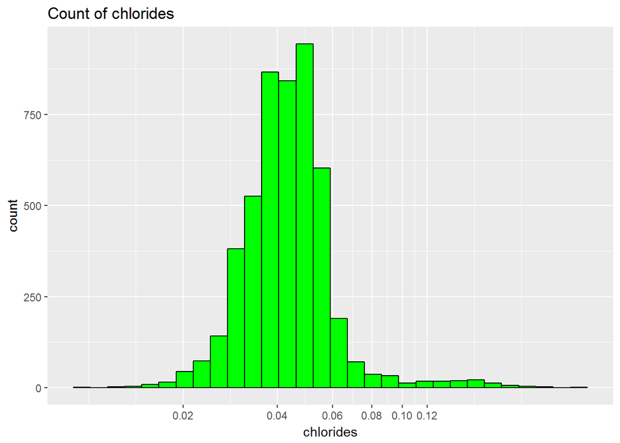

```r
ggplot(aes(x=chlorides),data=wines_df)+
  geom_histogram(color=I('black'),fill=I('green'))+
  #scale_x_continuous(limits = c(0.6,22),breaks = seq(0.6,22,2))+
  scale_x_log10(breaks =seq(0,0.12,0.02))+
  ggtitle('Count of chlorides')
```

chlorides has a normalized curve and it is also log transformed to extract data with median of 0.04 and mean of 0.045 .

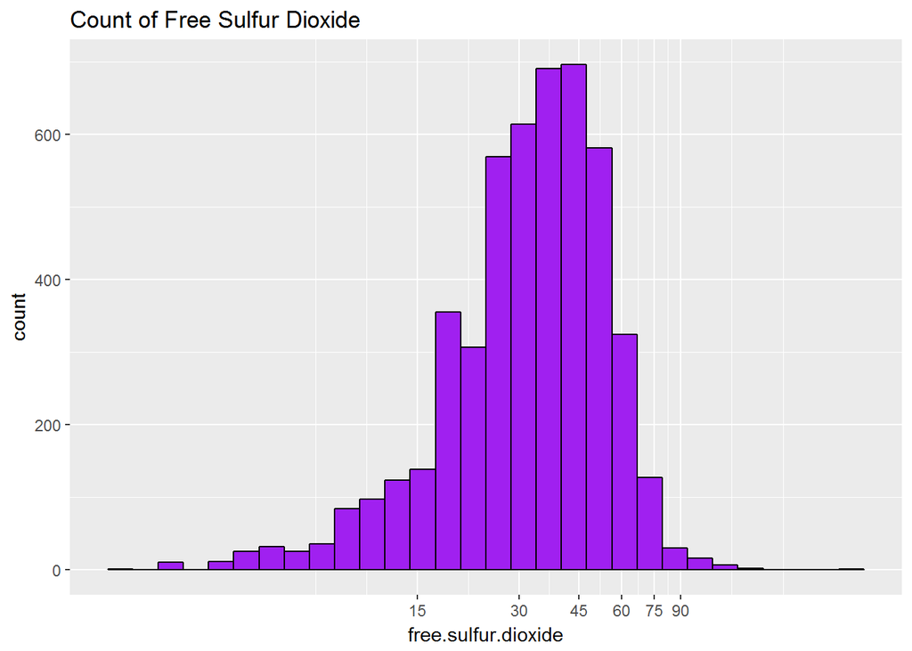

```r
ggplot(aes(x=free.sulfur.dioxide),data=wines_df)+
  geom_histogram(color=I('black'),fill=I('purple'))+
  #scale_x_continuous(limits = c(0.6,22),breaks = seq(0.6,22,2))+
  scale_x_log10(breaks=seq(0,101,15))+
  ggtitle('Count of Free Sulfur Dioxide')
```

free sulfur dioxide has a normalized curve and log transformed to extract bulk of data with medain of 34 and mean of 35.31

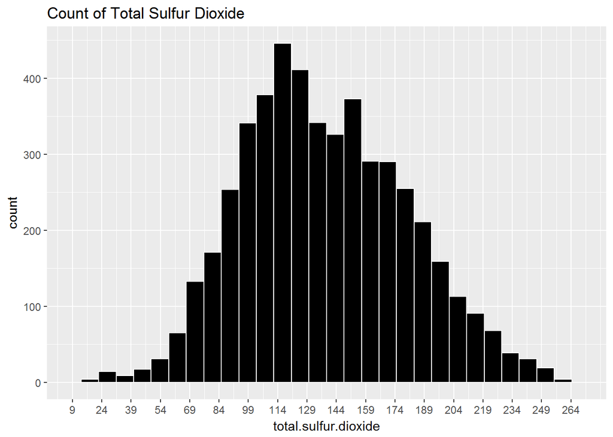

```r
ggplot(aes(x=total.sulfur.dioxide),data=wines_df)+
  geom_histogram(color=I('white'),fill=I('black'))+
  #coord_cartesian(xlim=c(0.9871,1.005)+
  scale_x_continuous(limits = c(9,269),breaks = seq(9,269,15))+
  #scale_x_log10()+
  ggtitle('Count of Total Sulfur Dioxide')
```

total sulfur dioxide has a similar bell shaped curve with median of 134 and mean of 138.4

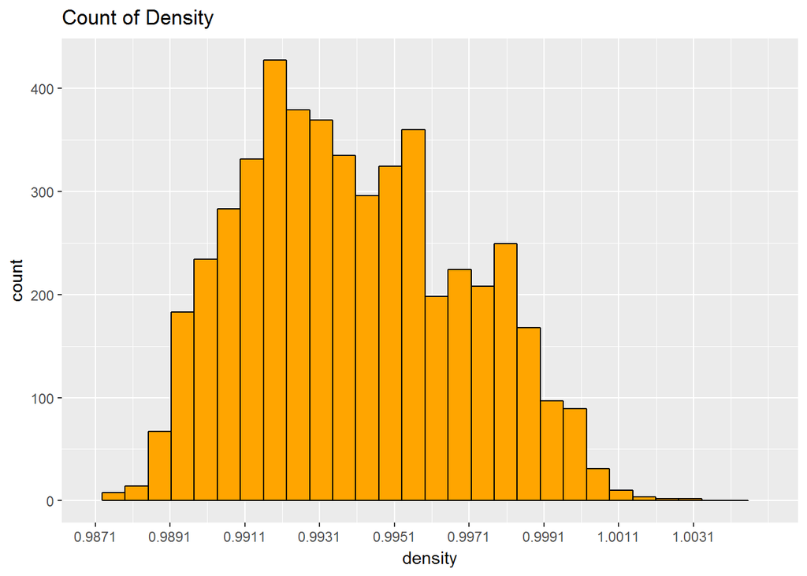

```r
ggplot(aes(x=density),data=wines_df)+
  geom_histogram(color=I('black'),fill=I('orange'))+
  #coord_cartesian(xlim=c(0.9871,1.005)+
  scale_x_continuous(limits = c(0.9871,1.005),breaks = seq(0.9871,1.005,0.002))+
  #scale_x_log10()+
  ggtitle('Count of Density')
```

density is in a small range of 0.987 to 1.03 with median of 0.993 and mean of 0.994

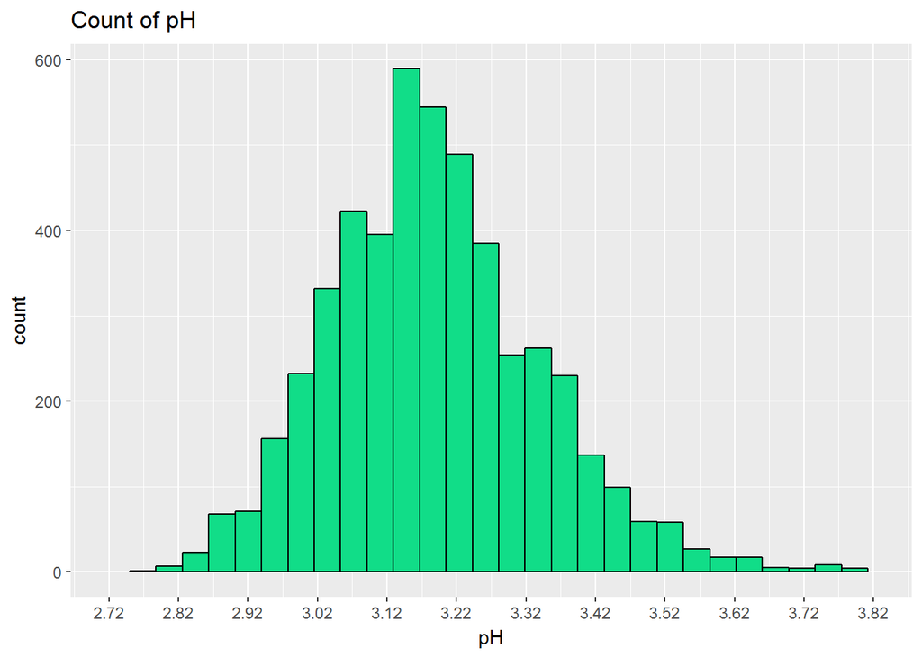

```r
ggplot(aes(x=pH),data=wines_df)+
  geom_histogram(color=I('black'),fill=I('#11dd88'))+
  #coord_cartesian(xlim=c(0.9871,1.005)+
  scale_x_continuous(limits = c(2.720,3.82),breaks = seq(2.720,3.82,0.1))+
  #scale_x_log10()+
  ggtitle('Count of pH')
```

Ph has a bell shaped curve with median of 3.18 and mean of 3.188 .

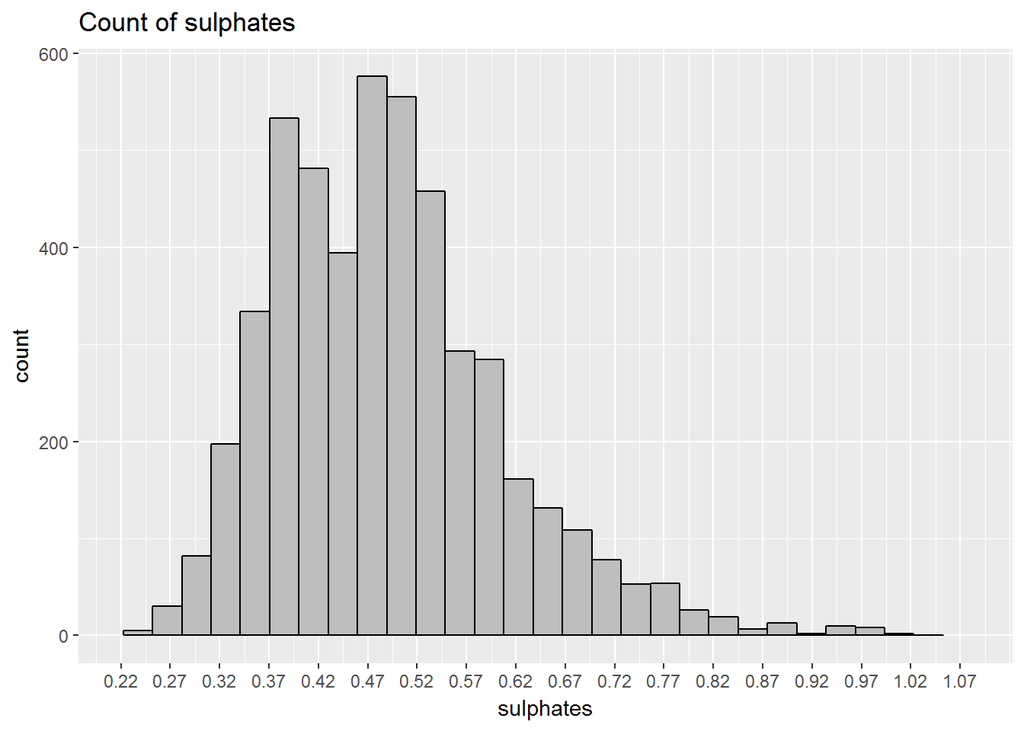

```r
ggplot(aes(x=sulphates),data=wines_df)+
  geom_histogram(color=I('black'),fill=I('grey'))+
  #coord_cartesian(xlim=c(0.9871,1.005)+
  scale_x_continuous(limits = c(0.22,1.08),breaks = seq(0.22,1.08,0.05))+
  #scale_x_log10()+
  ggtitle('Count of sulphates')
```

Sulphates have a similar to bimodal curve beacuse of a dip in center with median of 0.47 and mean of 0.49 .

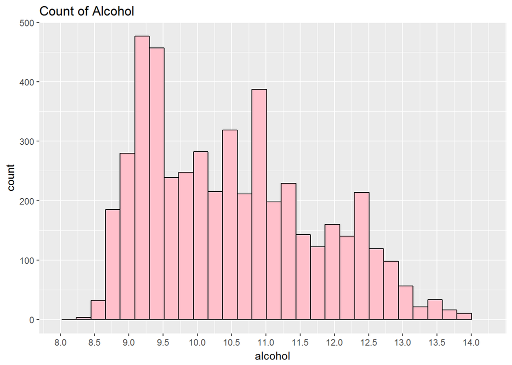

```r
ggplot(aes(x=alcohol),data=wines_df)+
  geom_histogram(color=I('black'),fill=I('pink'))+
  #coord_cartesian(xlim=c(0.9871,1.005)+
  scale_x_continuous(limits = c(8,14.20),breaks = seq(8,14.20,0.5))+
  #scale_x_log10()+
  ggtitle('Count of Alcohol')
```

Alcohol does not have a defined shape but its median of 10.4 and mean of 10.5

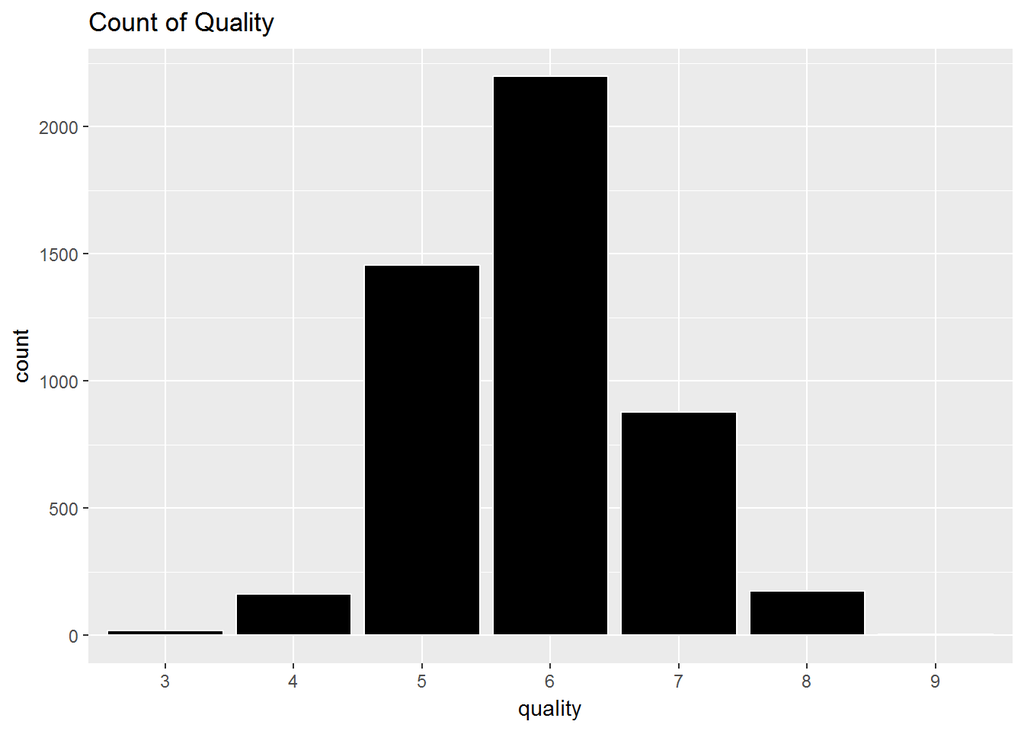

```r
ggplot(aes(x=quality),data=wines_df)+
  geom_bar(color=I('white'),fill=I('black'))+
  #scale_x_continuous(breaks = seq(3,9,1))+
  ggtitle('Count of Quality')
```

```r
summary(wines_df$quality)
```

```
##    3    4    5    6    7    8    9
##   20  163 1457 2198  880  175    5
```

Quality has some single distinct values like 3,4,5 etc with meadian of 6 and mean of 5.8 .

# Univariate Analysis

### Did you create any new variables from existing variables in the dataset?

# Bivariate Plots Section

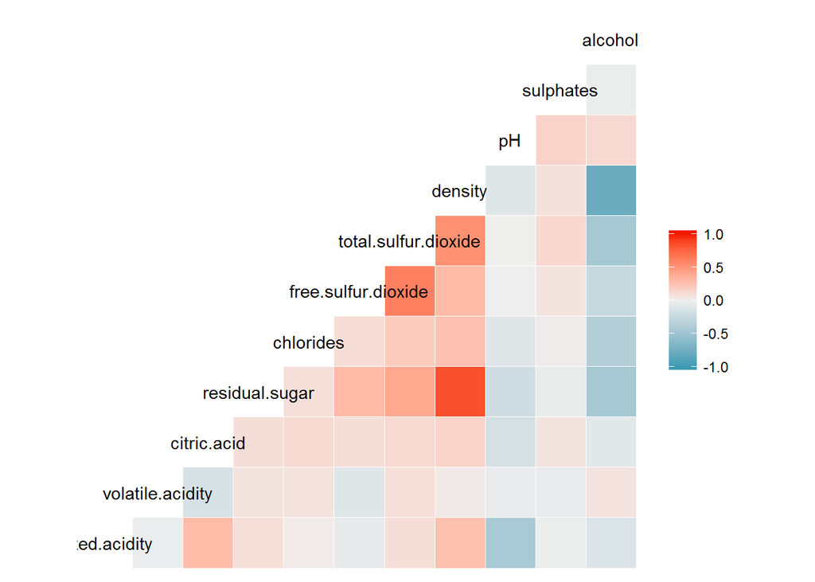

to see relationships and correlation of different variables with each other in one plot.

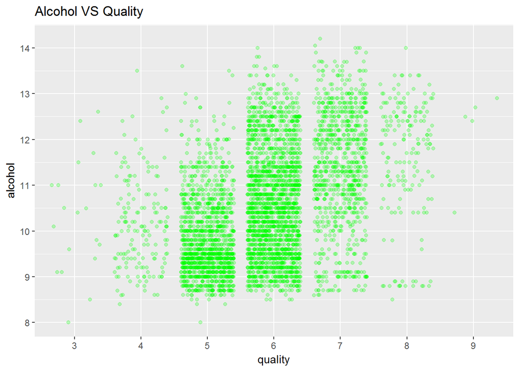

```r
ggplot(aes(y=alcohol,x=quality),data=wines_df)+geom_jitter(color='green',alpha=1/4)+
  scale_y_continuous(breaks = seq(8,16,1))+
  scale_x_discrete(breaks = seq(3,9,1))+

  ggtitle('Alcohol VS Quality')
```

we see here, as alcohol content increases quality increases not in linear fashion but it progresses slowly.

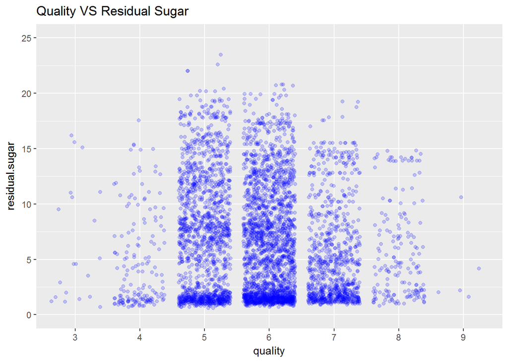

```r
ggplot(aes(y=residual.sugar,x=quality),data=wines_df)+geom_jitter(alpha=1/5,color='blue')+
  scale_x_discrete(breaks = seq(3,9,1))+
  scale_y_continuous(limits=c(0,25),breaks = seq(0,25,5))+
  ggtitle('Quality VS Residual Sugar')
```

every quality wine has majorly low levels of residual sugar.

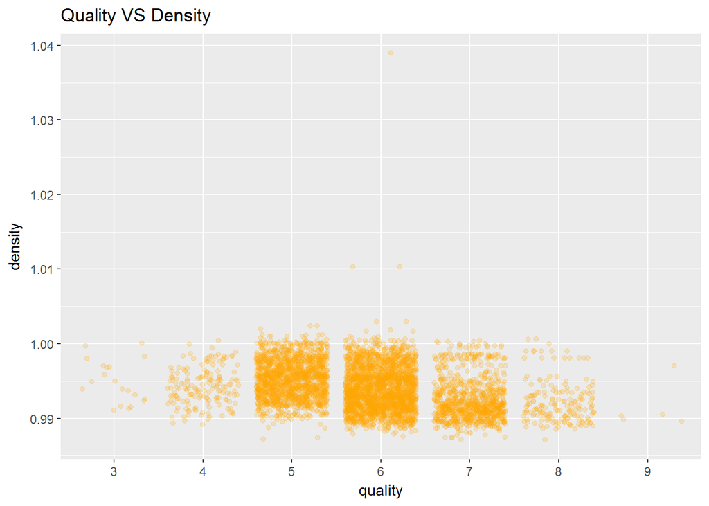

```r
ggplot(aes(x=quality,y=density),data=wines_df)+geom_jitter(alpha=1/5,color='orange')+
  scale_x_discrete(breaks = seq(3,9,1))+
  ggtitle('Quality VS Density')
```

Density of every Quality wine is in 0.99 to 1 range cannot conclude much about rating from this.

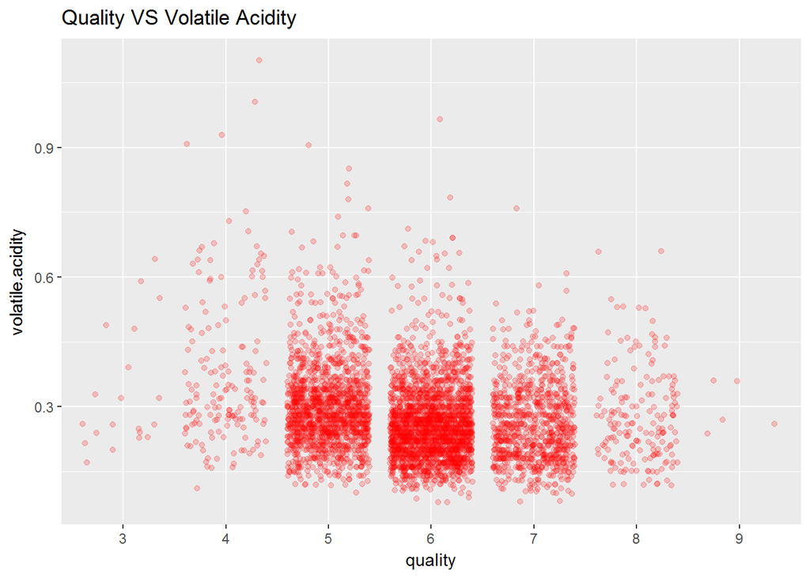

```r
ggplot(aes(x=quality,y=volatile.acidity),data=wines_df)+geom_jitter(alpha=1/5,color='red')+
  scale_x_discrete(breaks=seq(3,9,1))+
  ggtitle('Quality VS Volatile Acidity')
```

For Quality VS Volatile Acidity , for every quality the bulk of data lies below 0.33 which is valid because high levels of acidity will give unpleasent and vinegar like taste to wine.

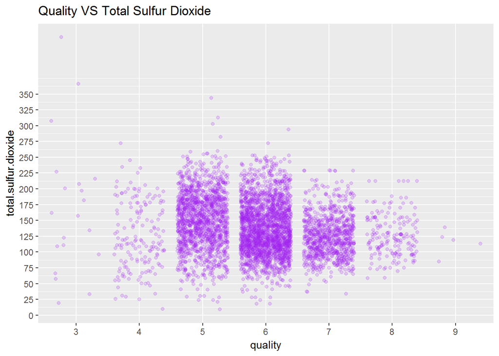

```r
ggplot(aes(x=quality,y=total.sulfur.dioxide),data=wines_df)+
  geom_jitter(alpha=1/5,color='purple')+
  scale_x_discrete(breaks=seq(3,9,1))+
  scale_y_continuous(breaks = seq(0,350,25))+
  ggtitle('Quality VS Total Sulfur Dioxide')
```

For Quality VS Total sulfur dioxide , lower levels of total sulfur dioxide will yield better quality wine.

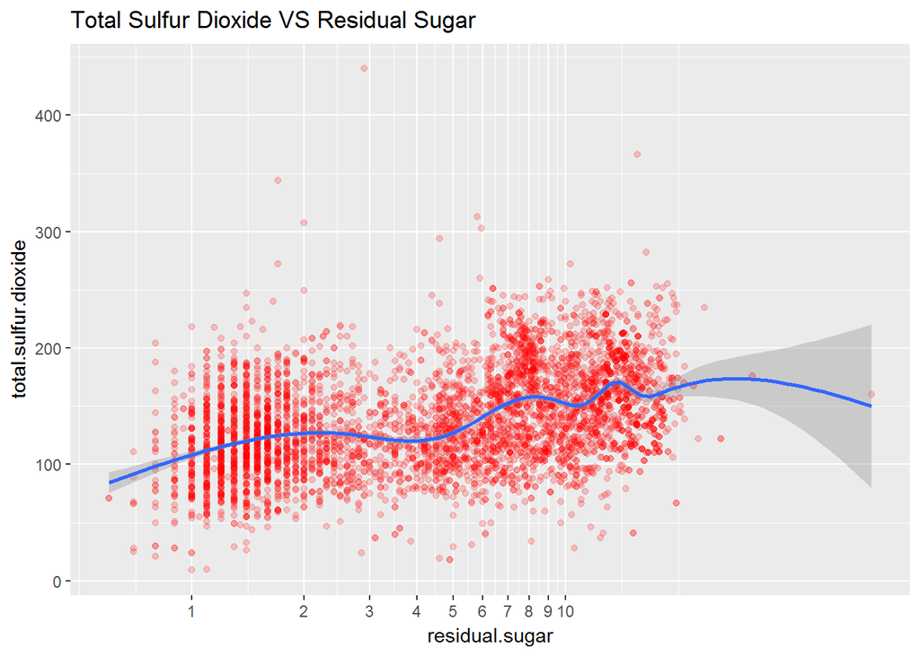

```r
ggplot(aes(x=residual.sugar,y=total.sulfur.dioxide),data=wines_df)+
  geom_point(color='red',alpha=1/5)+
  scale_x_log10(breaks=seq(1,10,1))+
  geom_smooth()+
  ggtitle('Total Sulfur Dioxide VS Residual Sugar')
```

we had total sulfur dioxide VS Residual sugar,when we plot it we get a bimodal scatterplot we have also seen bimodal histogram in univariate analysis of residual sugar, we see an increase in total sulfur dioxide where residual sugar is more and a dip where residual sugar is less maybe it is to balance out the sweetness in wine.

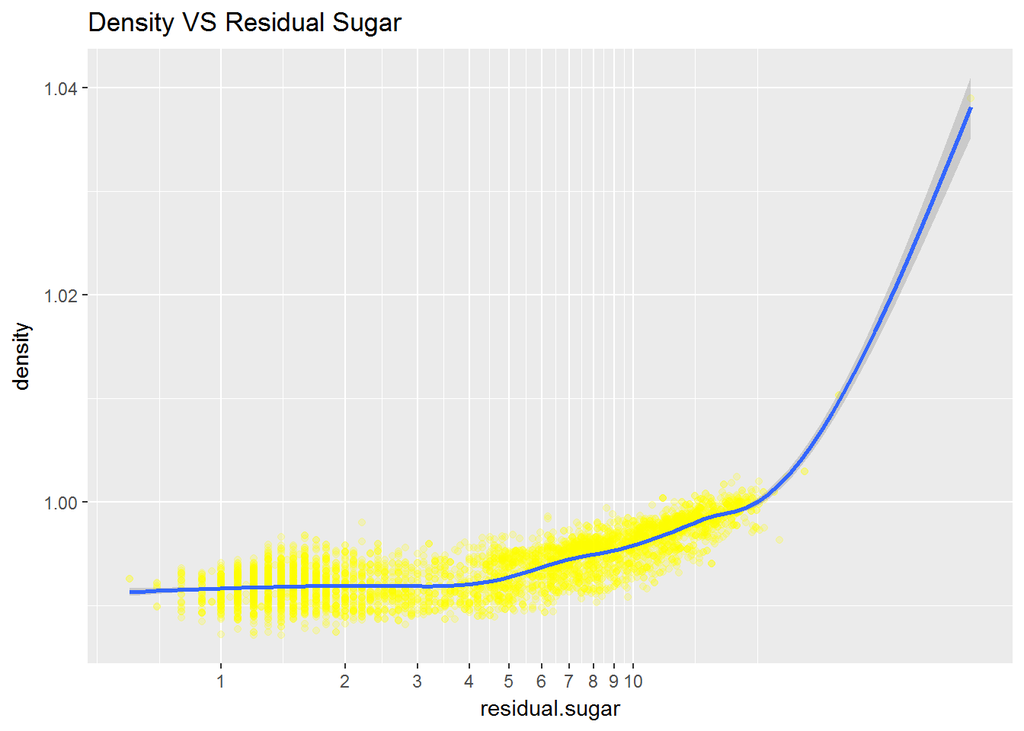

```r
ggplot(aes(x=residual.sugar,y=density),data=wines_df)+
  geom_point(color='yellow',alpha=1/5)+
  scale_x_log10(breaks=seq(1,10,1))+
  geom_smooth()+
  ggtitle('Density VS Residual Sugar')
```

For Density VS Residual Sugar , we see that with increase in residual sugar the density of wine increases which was expected as residual sugar is left over sugar after fermentation.They have a strong +ve correlation which can also be seen from graph.

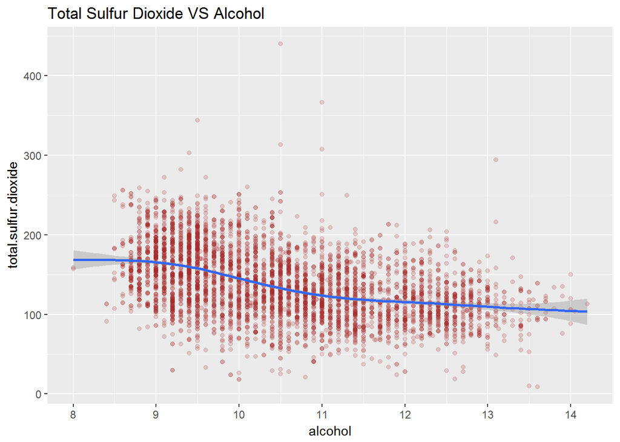

```r
ggplot(aes(x=alcohol,y=total.sulfur.dioxide),data=wines_df)+
  geom_point(alpha=1/5,color = 'brown')+
  scale_x_continuous(breaks=seq(8,14,1))+
  geom_smooth()+
  ggtitle('Total Sulfur Dioxide VS Alcohol')
```

For Total sulfur Dioxide VS Alcohol we see as alcohol content increases we see a decrease in total sulfur dioxide maybe we could get a clearer image when we plot alcohol vs total sulfur dioxide vs quality.

# Bivariate Analysis

### Talk about some of the relationships you observed in this part of the investigation. How did the feature(s) of interest vary with other features in the dataset?

ANS- Firstly the most frequent quality rating given is 5,6 and 7 ,4 and 8 are moderate and 3 and 9 are very rare.

[output not shown]

### Did you observe any interesting relationships between the other features (not the main feature(s) of interest)?

ANS- other than major features we had total sulfur dioxide VS Residual sugar,when we plot it we get a bimodal scatterplot we have also seen bimodal histogram in univariate analysis of residual sugar, we see an increase in total sulfur dioxide where residual sugar is more and a dip where residual sugar is less maybe it is to balance out the sweetness in wine.

### What was the strongest relationship you found?

ANS-There were 2 strong relationship: 1. If we talk about strongest then it was of residual sugar VS Density. 2. If we talk about the question we are trying to answer i.e what factors decide the quality of wine, then its Alcohol VS Quality.

# Multivariate Plots Section

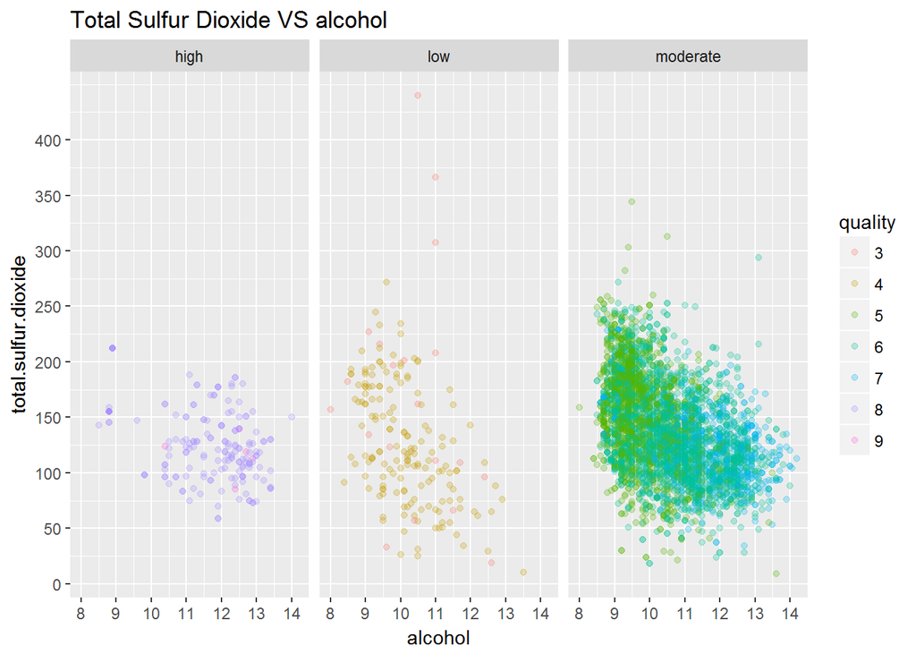

```r
ggplot(aes(y=total.sulfur.dioxide,x=alcohol),data = wines_df)+
  geom_point(aes(color=quality),alpha=1/4)+
  scale_x_continuous(breaks = seq(8,14,1))+
  facet_wrap(~ quality_rating)+
  scale_y_continuous(breaks = seq(0,400,50))+
  ggtitle('Total Sulfur Dioxide VS alcohol')
```

It seems like high alcohol content and low total sulfur dioxide will give a better quality wine.

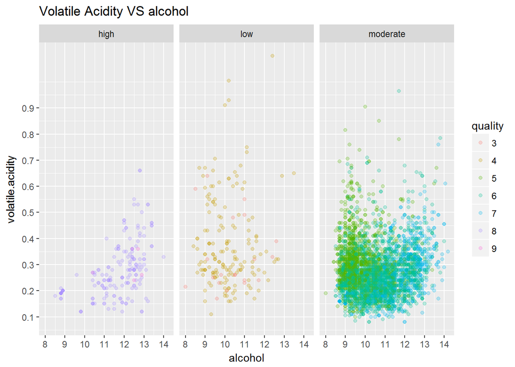

```r
ggplot(aes(y=volatile.acidity,x=alcohol),data = wines_df)+
  geom_point(aes(color=quality),alpha=1/4)+
  scale_x_continuous(breaks = seq(8,14,1))+
  facet_wrap(~ quality_rating)+
  scale_y_continuous(breaks = seq(0,0.9,0.1))+
  ggtitle('Volatile Acidity VS alcohol')
```

It looks like with low levels of volatile acidity and high alcohol content gives a good quality wine.

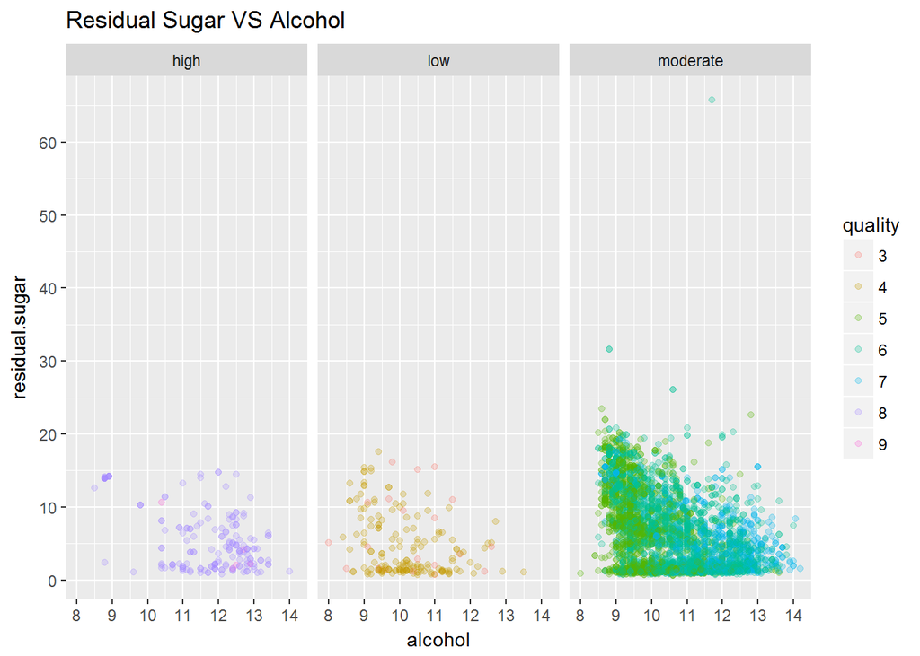

```r
ggplot(aes(y=residual.sugar,x=alcohol),data = wines_df)+
  geom_point(aes(color=quality),alpha=1/4)+
  scale_x_continuous(breaks = seq(8,14,1))+
  facet_wrap(~ quality_rating)+
  scale_y_continuous(breaks = seq(0,60,10))+
  ggtitle('Residual Sugar VS Alcohol')
```

residual Sugar is low for bulk of data and here quality depends solely on alcohol.

# Multivariate Analysis

### Talk about some of the relationships you observed in this part of the investigation. Were there features that strengthened each other in terms of looking at your feature(s) of interest?

# Final Plots and Summary

### Plot One

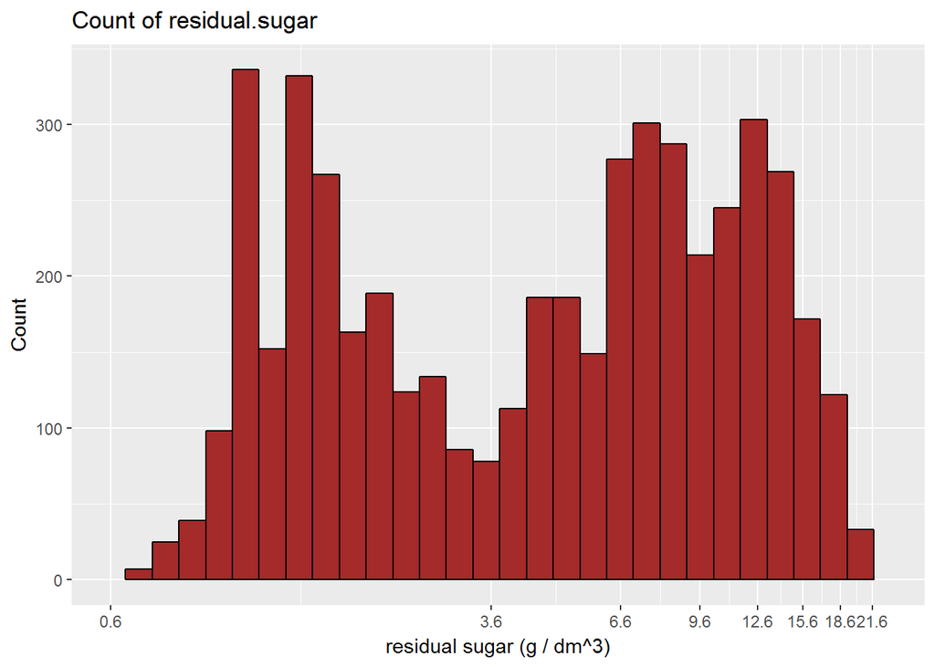

### Description One

Residual Sugar is a bimodal graph,which is log transformed to extract the bulk of data and it was intresting to find that majority of white wines either have low residual sugar or have high residual sugar.This was not being expected because wines dont have a sweet taste and thus should have low residual sugar.

### Plot Two

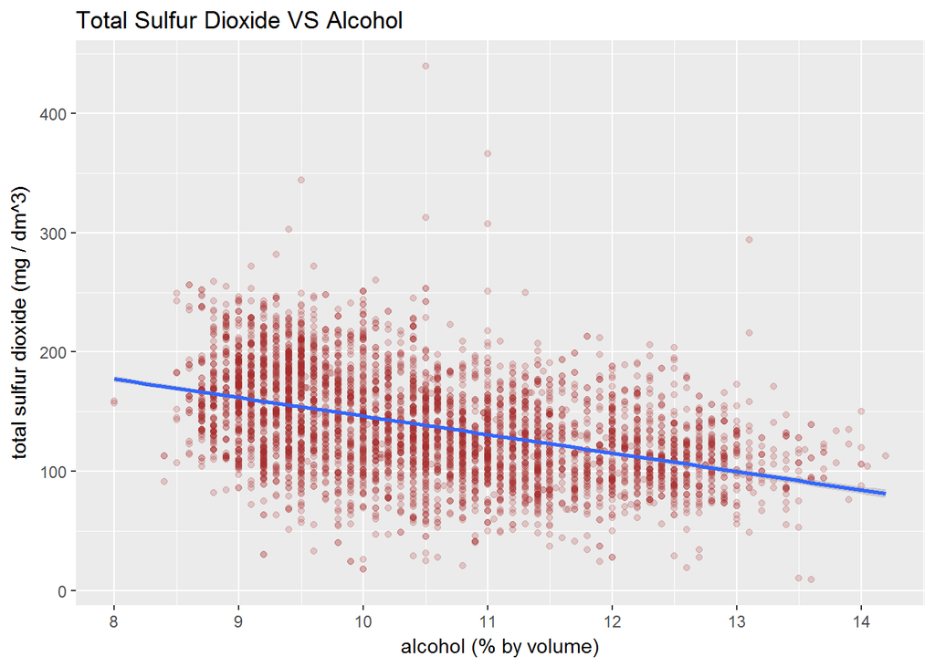

### Description Two

In total sulfur dioxide VS alcohol we see that with increase of alcohol percentage the levels of total sulfur dioxide decreases as we know from previous graphs that wines with higher alcohol percentage have better quality and total sulfur dioxide is responsible for evident smell of wine,this graph shows that as alcohol percentage will increase the smell of wine becomes less evident due to decrease in total sulfur dioxide.

### Plot Three

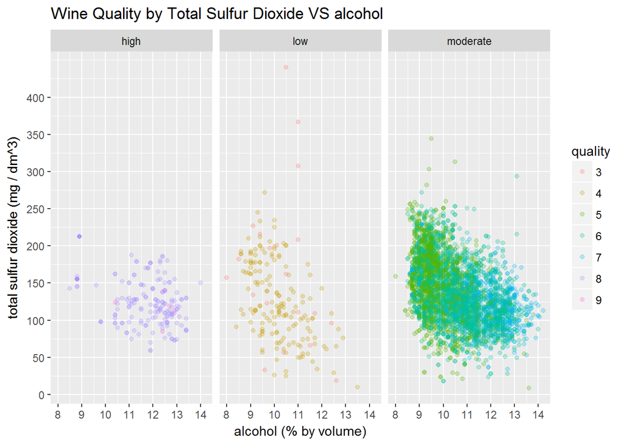

### Description Three

# Reflection

This as a white wine data set with 4898 observations and 13 varaibles initially then during the analysis I added a new varaible know as the quality rating which a categorical varaible which distinguishes wines on basis of their quality in low ,moderate or high.the dataset is tidy and without attribute values.Quality is the output variable and remaing are the input variable which decide the yielding of a good Quality wine. the struggles were that most of white wines in dataset have moderate rating i.e 5,6,7 and the low and high quality wines have very less data points hence bulk of data lied in moderate range hence there was a lot of overplotting in moderate section and very few information(data points) were available for low and high quality wines. A lot of data was skewed hence it needed to be transformed to get to the bulk of data ,categorical variables needed to be created to carry out the analysis neatly. The most surprising relations I found were total sulfur dioxide has alot of effect in deciding the quality of wine besides alcohol percentage,the density of wines lies in same range og 0.99 to 1. Later in analysis we found out that that low levels of total sulfur dioxide and high percentage of alcohol yields better white wine .A similar graph was shown with volatile acdity vs alcohol by quality. Future work can be done on dataset if more opinion of different people were taken to determine the quality of white wine as differrnt people will rate wines how they felt abot the taste and smell and then may be we would be able to make better predictions and analyse it more approprietly.